# Quantification of lysis/colicin gene families in Salmonella using profile-HMM

November 29, 2018

## Background: Colicin expression

- **Colicin:** Colicins are released into the environment to reduce competition from other bacterial strains. Virtually all colicins are carried on plasmids.
- **Two colicin groups:** The fundamental difference between the two groups may lie in the molecular weight of the plasmid DNA.
- **Lysis:** Colicin is only released from a producing cell by the use of the lysis protein, which results in that cell's death. ,

## Aim:

- For all *Salmonella* genomes, **quantification** of presence of colicin (and which type), lysis genes and prophages in their genome to understand their interplay.
- **Hypothesis:** Difference in prophage abundnace of *Salmonella* that express group A colicin compared to group B
- **But:** Many proteins are not annotated, we miss a lot if we just perform a search on annotated ORF names only
- **Solutoin:** Using profile-HMM instead of a blast search because it can find homologs of protein sequence

## Introduction: profile-HMM

A set of sequences can be aligned against each other resulting in a multiple sequence alignement (MSA)

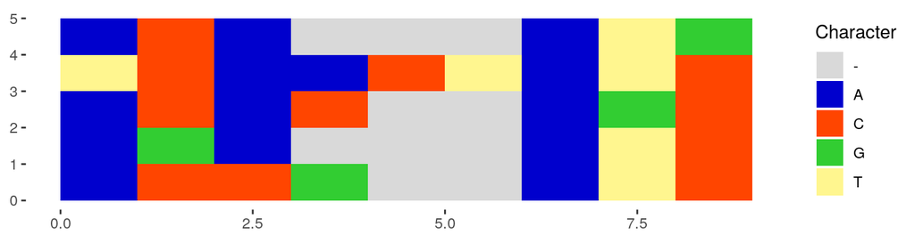

visual representation of the MSA

```bash
seq1: ACA---ATG
seq2: TCAACTATC
seq3: ACAC--AGC
seq4: AGA---ATC
seq5: ACCG--ATC
```

## from MSA to profile-HMM

- A profile HMM is a linear state machine consisting of a sereis of nodes, each of which corresponds roughly to a position (column) in the alignment.
- If we ignore gaps, the HMM would have one node for each column in alignment.
- Frequency inside each state is called **emission probability**

[figure not shown]

HMM model with 7 states and 1 internal state

## from MSA to profile-HMM

**But** would be the following sequence part of the familiy?

```bash
new sequence: GCAATG
```

No, thus it's common to include **pseudocounts** artificially when building the model

[figure not shown]

HMM model with 7 states and 1 internal state and pseudocounts

## profile-HMM

- HMMs to represent a family of sequences
- each column in the alignment may be represented by a hidden state that produced that column

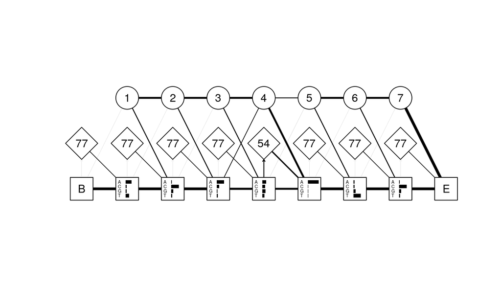

full profile HMM model with deletion and insertion states

```bash
hmmbuild example.hmm example.fatsa
```

The transition probabilities "from" a state always add up to 1

## profile-HMM

- Biological sequences are typically grouped into families with a certain functionality
- A relevant task is that of detecting whether a target sequence belongs to a certain family
- This could be done aligning the sequence to each of the sequences from the family
- However, pairwise alignments alone can miss cases of distantly related sequences
- A better way to detect such relationship would be: (i) building a model of the family (ii) testing whether the target sequence is compatible with the model

## searching for gene families (lysis)

These were searched using the [Pfam website](https://pfam.xfam.org/search#tabview=tab2) for involved genes from [Ry. Young, 2014](https://www.ncbi.nlm.nih.gov/pmc/articles/pmid/24585055/)

gene families for prophage lysis-genes

| group | description | ID |
| --- | --- | --- |
| lysin | endolysin + lysome | PF00959 |
| lysin | canonical holin | PF04971 |
| lysin | canonical endolysin | PF11860 |
| lysin | i-spanin | PF03245 |
| lysin | o-spanin | PF06085 |

## searching for gene families (colicin)

List of colicins are taken from https://de.wikipedia.org/wiki/Colicine. UniRef terms serached via [UniProt](https://www.uniprot.org/uniref/) with the search term *uniref50 "colicin B"*

Uniref for colicin genes

| group | description | ID |
| --- | --- | --- |
| B | Cluster: Colicin-B | UniRef50_P05819 |
| B | Cluster: Colicin-D | UniRef50_P17998 |
| A | Cluster: Colicin-E1 | UniRef50_P02978 |
| A | Cluster: Colicin-E9 | UniRef50_P09883 |
| none | Cluster: Colicin-E5 | UniRef50_UPI00022A9A6A |
| B | Cluster: Colicin FY | UniRef50_H8YUQ0 |
| B | Cluster: Colicin-Ia | UniRef50_P06716 |
| none | Cluster: Colicin-K | UniRef50_Q47502 |
| A | Cluster: Colicin-N | UniRef50_P08083 |
| B | Cluster: Colicin-M | UniRef50_P05820 |
| A | Cluster: Colicin Y | UniRef50_Q9KJ98 |
| B | Cluster: Colicin V | UniRef50_A0A0W0TIU2 |

## MSA of Colicin V

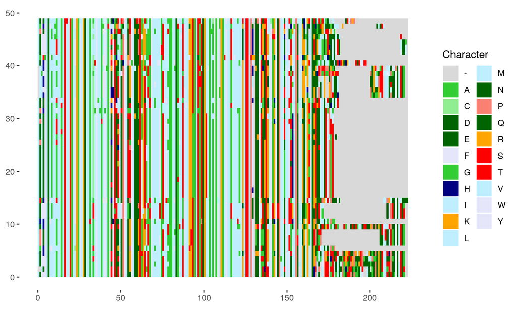

visual representation of the MSA

## MSA of Colicin-E1

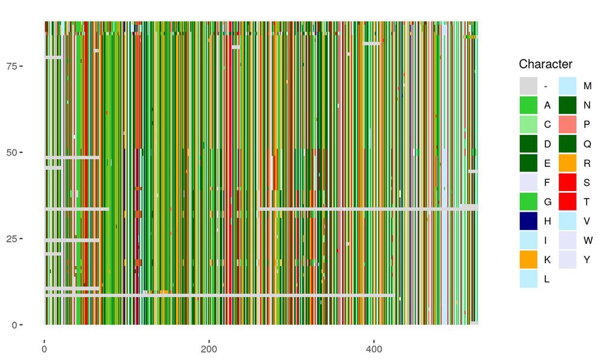

visual representation of the MSA

## MSA of Colicin-B

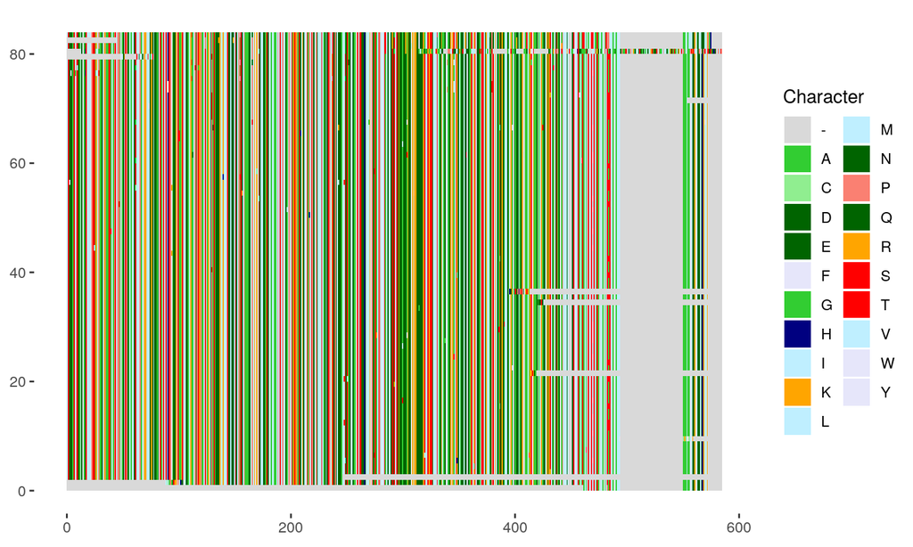

visual representation of the MSA

## MSA of Colicin-M

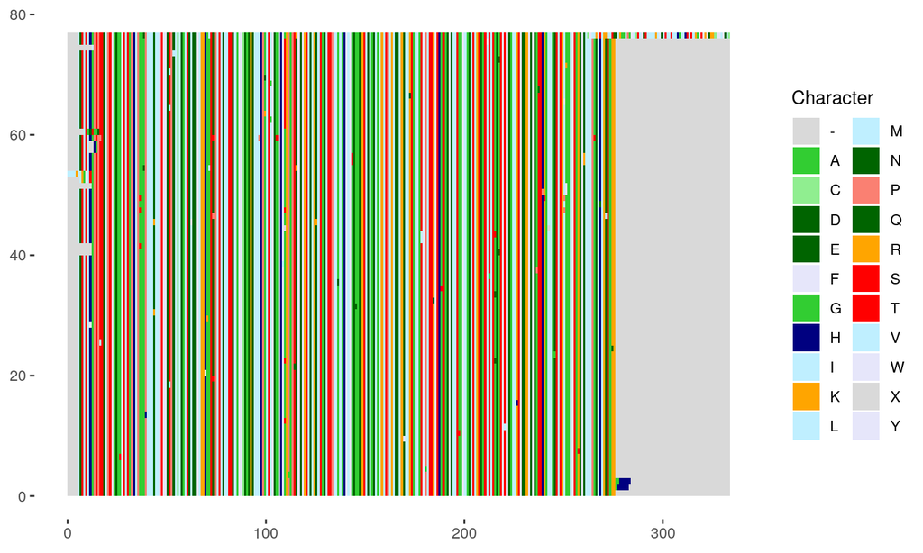

visual representation of the MSA

## MSA of Colicin-Ia

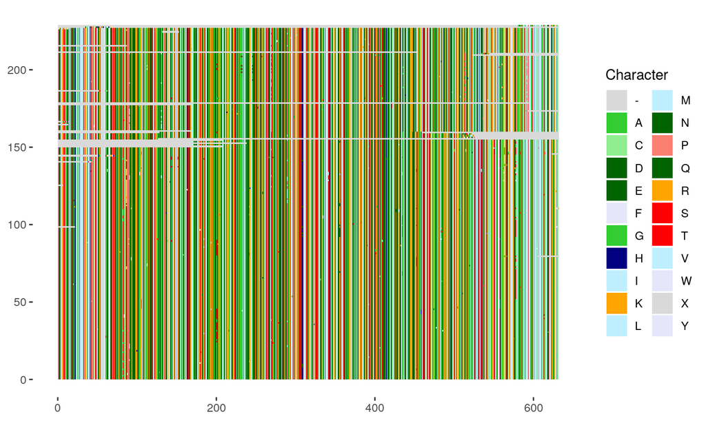

visual representation of the MSA

## MSA of Colicin-N

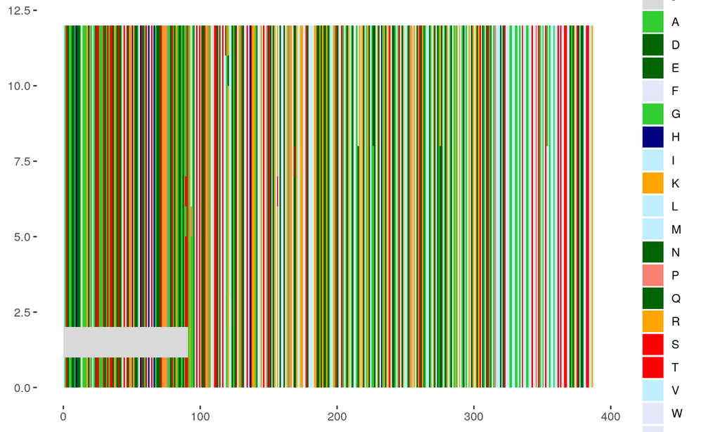

visual representation of the MSA

## MSA of Colicin-E9

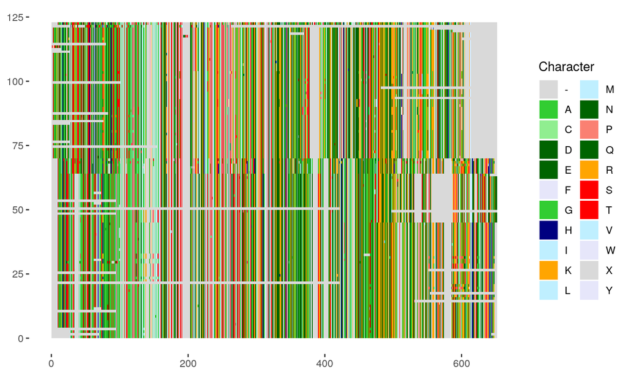

visual representation of the MSA

## MSA of Colicin-D

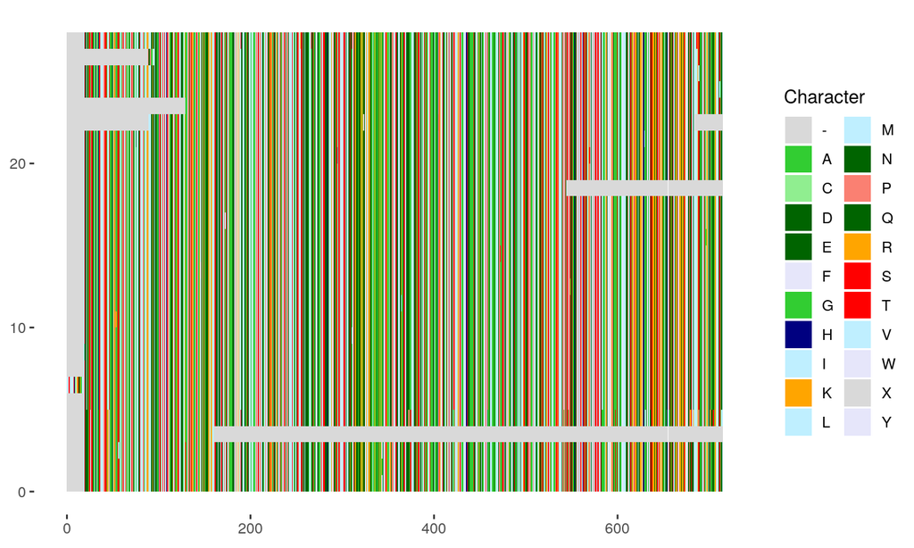

visual representation of the MSA

## MSA of Colicin-K

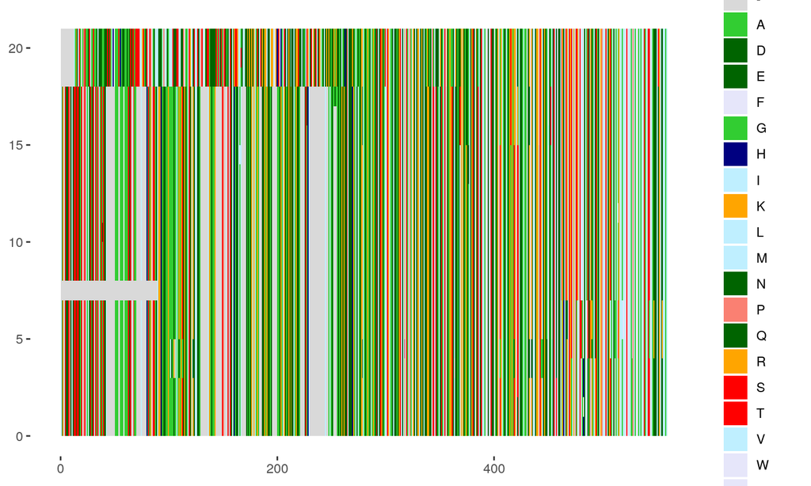

visual representation of the MSA

## MSA of Colicin Y

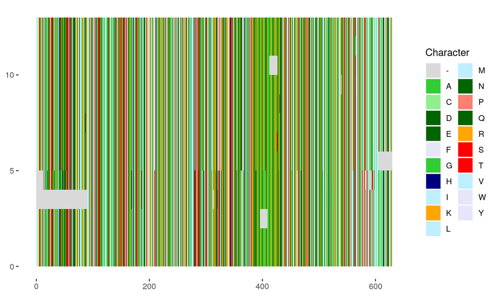

visual representation of the MSA

## MSA of Colicin-E5

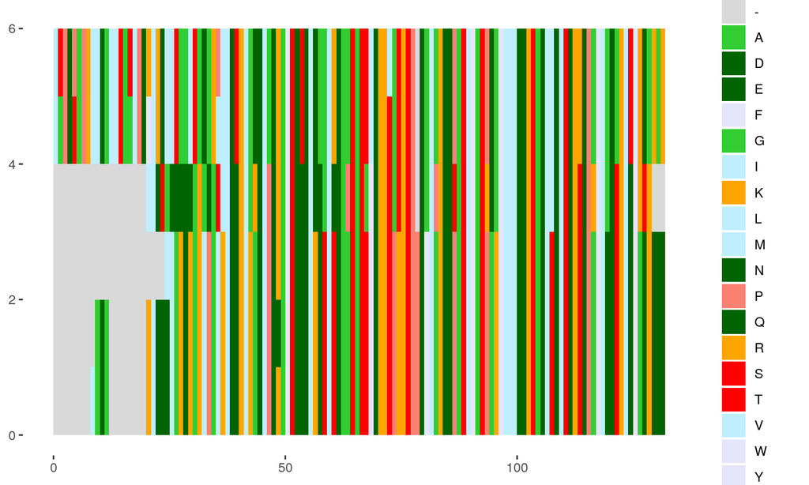

visual representation of the MSA

## profile-HMM of Colicin V

The profile-HMM are quite large, but we can visualize the first few states

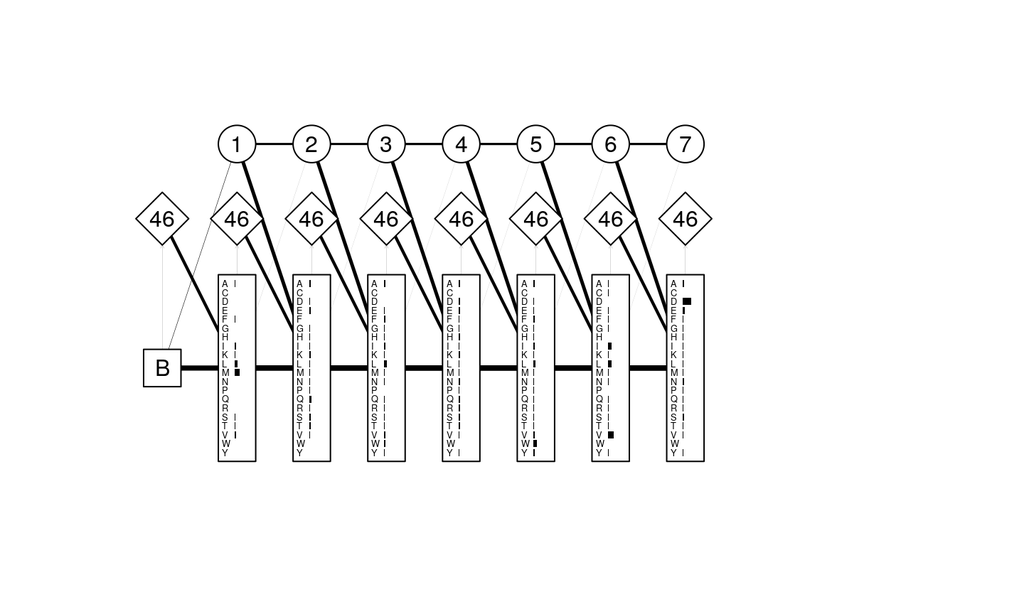

## profile-HMM of Colicin-E5

The profile-HMM are quite large, but we can visualize the first few states

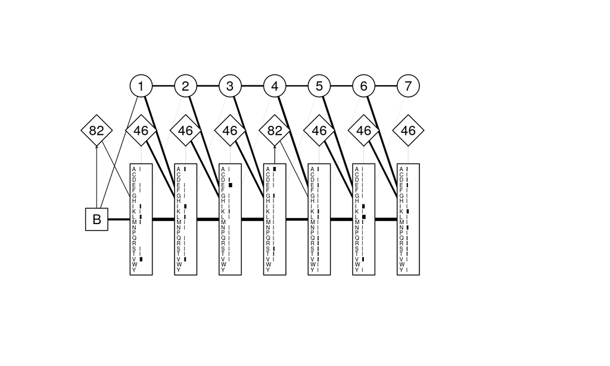

## prepreating *Salmonella genomes*

Downloaded from [NCBI genome browser](https://www.ncbi.nlm.nih.gov/genome/browse/) using the search term *"Salmonella enterica"* resulting in 9754 entries.

## Detection of prophages

We use PhiSpy ([paper](https://www.ncbi.nlm.nih.gov/pmc/articles/PMC3439882/)) to detect prophages in genomes.

## Results: colicin/lysis occurence in *Salmonella* genomes

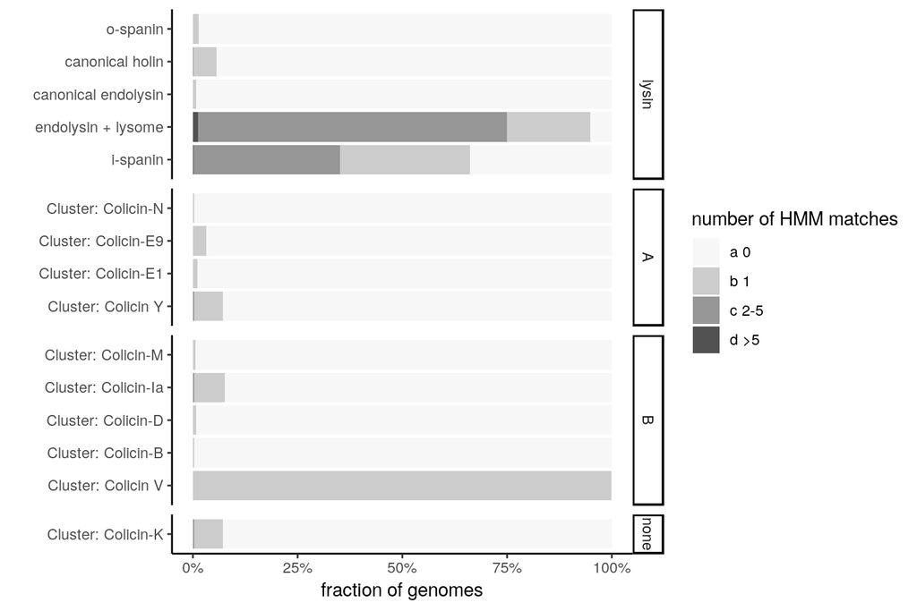

occurence of colicin and lysis gene families

## different way to plot

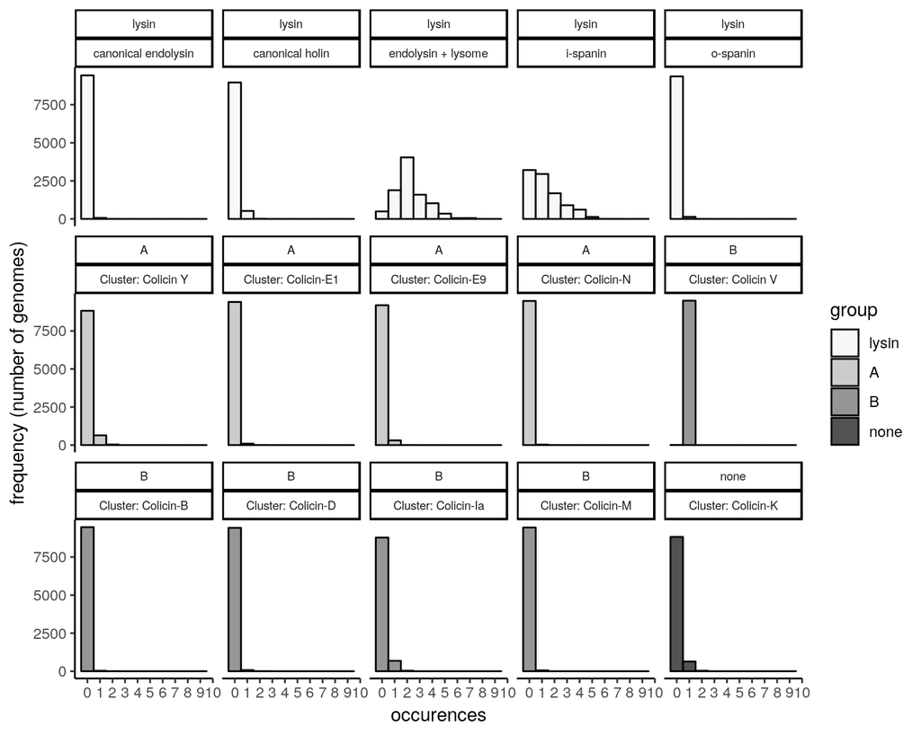

occurence of colicin and lysis gene families

## number of colicin/lysis gene families found on genomes

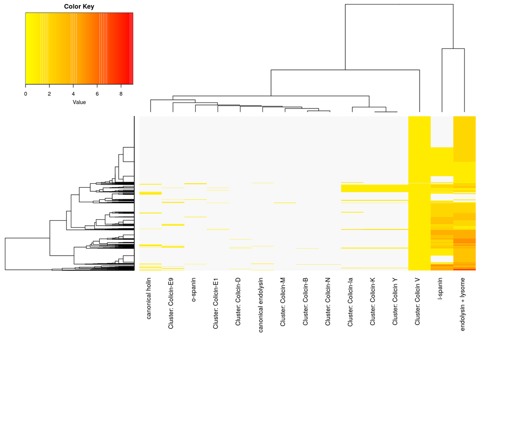

## validation of HMM matches (lysis)

To check whether the HMM matches are TP, we can check the ORF annotation of the HMM matching region. We use a grep on the terms "lys" and "hypotetical". It seems that most are annotated correctly.

```
## [1] "97% annotated as lysis"
```

```
## [1] "1% annotated as hypothetical"
```

ORF annotation of remaining matches

|  | Var1 | Freq |
| --- | --- | --- |
| 5 | endopeptidase [Salmonella enterica] | 65 |
| 2 | DUF3380 domain-containing protein [Salmonella enterica] | 61 |
| 21 | muraminidase, partial [Salmonella enterica] | 58 |
| 20 | muraminidase [Salmonella enterica] | 56 |

## validation of HMM machtes (colicin)

```
## [1] "95% annotated as colicin"
```

```
## [1] "3% annotated as hypothetical"
```

ORF annotation of remaining matches

|  | Var1 | Freq |
| --- | --- | --- |
| 2 | cloacin [Salmonella enterica] | 155 |
| 13 | pyocin [Salmonella enterica] | 54 |
| 11 | MULTISPECIES: HNH endonuclease [Enterobacteriaceae] | 8 |
| 14 | pyocin, partial [Salmonella enterica] | 7 |

## looking at individual colicin gene families

## Colicin ORF hits

Now we can spot check by hand the most occuring ORF annotations for Colicin clusters. We see here that some seems to be specific (e.g. Colicin V) while other are non specific and show matches to Colicin E and B for example. The number in the *dummy* column shows the number of ORF hits of the HMM model.

### B

|  | description2 | description | dummy |
| --- | --- | --- | --- |
| 60 | Cluster: Colicin-B | hypothetical protein [Salmonella enterica] | 8 |
| 128 | Cluster: Colicin-B | MULTISPECIES: pore-forming bacteriocin colicin B [Enterobacteriaceae] | 7 |
| 90 | Cluster: Colicin-B | MULTISPECIES: colicin B [Enterobacteriaceae] | 6 |
| 35 | Cluster: Colicin-B | colicin-A [Salmonella enterica] | 4 |
| 30 | Cluster: Colicin-B | colicin Y [Salmonella enterica] | 3 |
| 37 | Cluster: Colicin-B | colicin-B [Salmonella enterica] | 2 |
| 15 | Cluster: Colicin-B | colicin B [Salmonella enterica] | 1 |
| 18 | Cluster: Colicin-B | colicin immunity protein [Salmonella enterica] | 1 |
| 20 | Cluster: Colicin-B | colicin N [Salmonella enterica] | 1 |
| 50 | Cluster: Colicin-B | colicin, partial [Salmonella enterica] | 1 |

### M

|  | description2 | description | dummy |
| --- | --- | --- | --- |
| 66 | Cluster: Colicin-M | hypothetical protein [Salmonella enterica] | 33 |
| 99 | Cluster: Colicin-M | MULTISPECIES: colicin M [Enterobacteriaceae] | 9 |
| 127 | Cluster: Colicin-M | MULTISPECIES: lipid II-degrading bacteriocin colicin M [Enterobacteriaceae] | 8 |
| 73 | Cluster: Colicin-M | lipid II-degrading bacteriocin [Salmonella enterica] | 5 |
| 11 | Cluster: Colicin-M | colicin [Salmonella enterica] | 1 |
| 45 | Cluster: Colicin-M | colicin-M [Salmonella enterica] | 1 |
| 74 | Cluster: Colicin-M | lipid II-degrading bacteriocin colicin M, partial [Salmonella enterica] | 1 |